# 09 - Aula de Planejamento de Experimentos

Estatística

Essa aula irá abordar os conceitos e exemplos de Planejamento de Experimentos.

Author

Affiliation

Ludmilla Rodrigues Santana Borges

Universidade Federal da Bahia (UFBA)

Published

June 15, 2026

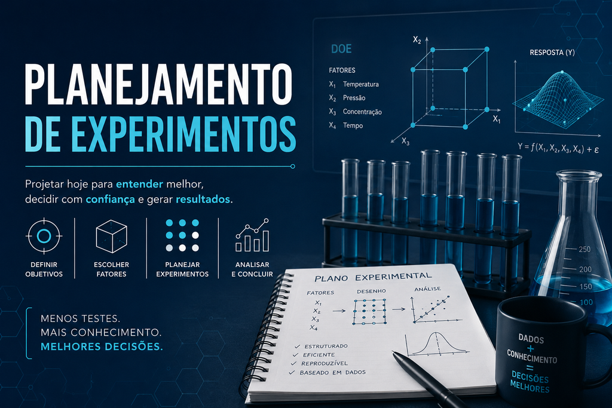

ChatGPT Image 13_06_2026, 12_59_36.png

# **Aula de Planejamento de Experimentos**

Essa aula irá abordar os conceitos e exemplos de Planejamento de Experimentos.

Os exemplos aqui apresentados irão abordar estudos voltados à implantação de projetos de urbanização.

## **1.Conceitos Fundamentais**

- **Experimento ou ensaio**

É um procedimento planejado e conduzidos de forma controlada sobre variáveis experimentais, para obter novos fatos, negar ou confirmar hipóteses.

Experimento - Avalia um conjunto completo

Ensaio - Testa uma medição especifica dentro do experimento.

- **Tratamento**

É a condição imposta ao experimento. Exemplo: Utilização de diferentes equipamentos, temperatura, método de preparação, entre outros.

Eles podem ser qualitativos ou quantitativos.

- **Unidade Experimental ou Parcela**

É onde é realizado o tratamento. A unidade experimental que fornece os dados para avaliação ou seja, é aqui que a variável resposta é medida.

- **Erro Experimental**

É a variação observada entre as unidades experimentais, após as mesmas serem submetidas ao mesmo tratamento.

- **E quais os objetivos?**

Aqui a ideia é obter resultados confiáveis, reduzindo custos e tempo de execução. Também vamos controlar fontes de variabilidade e aumentar a precisão das conclusões.

## **2.Delineamento Completamente Casualizado (DCC)**

Observação: Alguns autores podem chamar o DCC também de DIC (Delineamento Inteiramente Casualizado), mas são apenas traduções diferentes para o termo em inglês **Completely Randomized Design (CRD)**.

- **Conceito**

A casualidade é total, todos os tratamentos são distribuidos aleatoriamente entre asunidades experimentais consideradas homogêneas.

Pode ser utilizados quando as unidades experimentais são homogêneas. Esse delineamento é o mais simples da planejamento de experimentos.

- **Exemplo**

Em um projeto de urbanização, primeiramente é realizado o cadastro socioeconômico da população, onde todos os dados dos moradores são coletados, inclusives os endereços. Para analisar a distribuição espacial das familías, é possivel fazer a geocodificação desses endereços.

**Unidade experimental**: Endereços sorteados.

**Tratamento**: Google Maps, OpenStreetMAP e Bing Maps.

**Váriavel resposta**: Erro médio de posicionamento (m).

**Bibliotecas utilizadas:**

- Numpy - Operações numéricas
- Pandas - Leitura e manipulação da planilha
- Scipy.stats - Estatística e probabilidade
- statsmodels.stats.multicomp - Análises estatísticas avançadas
- matplotlib - Criação de gráficos

```
==============================
📌 Média dos Erros:
==============================

                   Média  Desvio Padrão    Mínimo     Máximo
Método
Bing           18.259585       4.337132  5.034931  33.410926
Google          7.792307       1.816337  2.760510  11.704556
OpenStreetMap  12.066914       2.861007  6.243686  20.160507

==============================
📌 ANOVA
==============================

F = 274.2772
p = 0.000000

Existe diferença significativa entre os métodos.

==============================
📌 TESTE DE TUKEY
==============================

  Grupo 1        Grupo 2  Diferença Média  Valor-p  Limite Inferior  \
0    Bing         Google         -10.4673      0.0         -11.5259
1    Bing  OpenStreetMap          -6.1927      0.0          -7.2513
2  Google  OpenStreetMap           4.2746      0.0           3.2160

   Limite Superior  Diferença Significativa
0          -9.4087                     True
1          -5.1341                     True
2           5.3332                     True
```

[figure not shown]

## **3.Delineamento em Blocos Casualizados (DBC)**

- **Conceito**

O delineamento em Blocos Casualizados (DBC) é utilizado quando as unidades experimentais não são homogêneas, contudo, elas podem ser agrupadas em grupos homogêneos, esses grupos são chamados de blocos. Para ser chamado de DBC, cada bloco precisa de pelo menos uma repetição de cada tratamento.

- **Exemplo**

Pegando o gancho do exemplo anterior, aqui iremos avaliar diferentes métodos de levantamento de cadastro socioeconômico das famílias. Vamos avaliar a eficiência de três métodos de levantamento do cadastro socioeconômico. Utilizando aplicativo móvel, planilha digital e formulário em papel. Como diferentes equipes de campo podem possuir níveis diferentes de experiência, então os metódos serão aplicados aleatoriamento pelas equipes.

**Unidade experimental**: Cadastro socioeconômico.

**Tratamento**: Aplicativo móvel, planilha digital e formulário em papel.

**Váriavel resposta**: Tempo médio de coleta por método.

**Blocos**: Equipes de Campo

**Bibliotecas utilizadas:**

- Numpy - Operações numéricas
- Pandas - Leitura e manipulação da planilha
- Scipy.stats - Estatística e probabilidade
- statsmodels.stats.multicomp - Análises estatísticas avançadas
- matplotlib - Criação de gráficos

```
📊 DADOS DO EXPERIMENTO
       Bloco        Tratamento      Tempo
0   Equipe_A         App_Movel  28.490142
1   Equipe_A  Planilha_Digital  36.585207
2   Equipe_A  Formulario_Papel  53.943066
3   Equipe_B         App_Movel  34.569090
4   Equipe_B  Planilha_Digital  39.297540
5   Equipe_B  Formulario_Papel  54.297589
6   Equipe_C         App_Movel  39.737638
7   Equipe_C  Planilha_Digital  47.302304
8   Equipe_C  Formulario_Papel  58.591577
9   Equipe_D         App_Movel  39.627680
10  Equipe_D  Planilha_Digital  46.609747
11  Equipe_D  Formulario_Papel  61.602811

==============================
📌 ANÁLISE DE VARIÂNCIA (DBC)
==============================

               Soma dos Quadrados  Graus de Liberdade  Estatística F   Valor p
C(Bloco)               193.310939                 3.0      22.549197  0.001146
C(Tratamento)          965.467781                 2.0     168.928802  0.000005
Residual                17.145705                 6.0            NaN       NaN

==============================
📌 MÉDIAS DOS TRATAMENTOS (min)
==============================

Tratamento
App_Movel           35.606138
Planilha_Digital    42.448700
Formulario_Papel    57.108761
Name: Tempo, dtype: float64

==============================
📌 TESTE DE TUKEY (5%)
==============================

       Tratamento 1      Tratamento 2  Diferença de Médias  Valor p ajustado  \
0         App_Movel  Formulario_Papel              21.5026            0.0004
1         App_Movel  Planilha_Digital               6.8426            0.1675
2  Formulario_Papel  Planilha_Digital             -14.6601            0.0052

   Limite Inferior  Limite Superior  Diferença significativa?
0          11.9557          31.0495                      True
1          -2.7043          16.3894                     False
2         -24.2069          -5.1132                      True
```

[figure not shown]

```
==============================
📌 RESUMO DO MODELO (OLS - DBC)
==============================

                            OLS Regression Results
==============================================================================
Dep. Variable:                  Tempo   R-squared:                       0.985
Model:                            OLS   Adj. R-squared:                  0.973
Method:                 Least Squares   F-statistic:                     81.10
Date:                Sat, 13 Jun 2026   Prob (F-statistic):           2.00e-05
Time:                        19:50:08   Log-Likelihood:                -19.168
No. Observations:                  12   AIC:                             50.34
Df Residuals:                       6   BIC:                             53.25
Df Model:                           5
Covariance Type:            nonrobust
=====================================================================================================
                                        coef    std err          t      P>|t|      [0.025      0.975]
-----------------------------------------------------------------------------------------------------
Intercept                            30.2244      1.195     25.285      0.000      27.300      33.149
C(Bloco)[T.Equipe_B]                  3.0486      1.380      2.209      0.069      -0.329       6.426
C(Bloco)[T.Equipe_C]                  8.8710      1.380      6.427      0.001       5.494      12.248
C(Bloco)[T.Equipe_D]                  9.6073      1.380      6.961      0.000       6.230      12.985
C(Tratamento)[T.Formulario_Papel]    21.5026      1.195     17.989      0.000      18.578      24.427
C(Tratamento)[T.Planilha_Digital]     6.8426      1.195      5.724      0.001       3.918       9.767
==============================================================================
Omnibus:                        0.047   Durbin-Watson:                   1.796
Prob(Omnibus):                  0.977   Jarque-Bera (JB):                0.259
Skew:                           0.088   Prob(JB):                        0.878
Kurtosis:                       2.302   Cond. No.                         5.35
==============================================================================

Notes:
[1] Standard Errors assume that the covariance matrix of the errors is correctly specified.
```

## **4.Delineamento em Quadrado Latino (DQL)**

- **Conceito**

O quadrado latino, ou como chamado por alguns autores de duplo bloqueamento, é utilizado para controle total. As variações elas são conhecidas e podem ser controladas. A casualização é feita para que tenha somente uma repetição de cada tratamento nos blocos, aparecendo em linhas e colunas. Por aparecer em linhas e colunas, o número de tratamentos devem ser iguais aos números de repetições. Ou seja, as linhas e colunas não são os dados principais do estudo, são os fatores de bloqueio (variáveis de controle).

- **Exemplo**

Vamos utilizar o mesmo exemplo do DBC, contudo, vamos acrescentar bairros como variável de controle.

**Unidade experimental**: Cadastro socioeconômico.

**Tratamento**: Aplicativo móvel, planilha digital e formulário em papel.

**Váriavel resposta**: Tempo médio de coleta por método.

**Blocos**: Equipes de Campo

**Váriavel de controle**: Bairros

**Bibliotecas utilizadas:**

- Numpy - Operações numéricas
- Pandas - Leitura e manipulação da planilha
- Scipy.stats - Estatística e probabilidade
- statsmodels.stats.multicomp - Análises estatísticas avançadas
- matplotlib - Criação de gráficos
- seaborn - Criação de gráficos

```
📊 Dados do experimento (Cadastro Socioeconômico)
```

|  | bairro | equipe | metodo | tempo |
| --- | --- | --- | --- | --- |
| 0 | B1 | E1 | App móvel | 12 |
| 1 | B1 | E2 | Planilha digital | 18 |
| 2 | B1 | E3 | Formulário papel | 25 |
| 3 | B2 | E1 | Planilha digital | 15 |
| 4 | B2 | E2 | Formulário papel | 22 |
| 5 | B2 | E3 | App móvel | 11 |
| 6 | B3 | E1 | Formulário papel | 24 |
| 7 | B3 | E2 | App móvel | 10 |
| 8 | B3 | E3 | Planilha digital | 17 |

```
📊 ANOVA - Delineamento em Quadrado Latino (DQL)
```

|  | sum_sq | df | F | PR(>F) |
| --- | --- | --- | --- | --- |
| C(metodo) | 241.555556 | 2.0 | 155.285714 | 0.006399 |
| C(bairro) | 8.222222 | 2.0 | 5.285714 | 0.159091 |
| C(equipe) | 1.555556 | 2.0 | 1.000000 | 0.500000 |
| Residual | 1.555556 | 2.0 | NaN | NaN |

```
📌 Tukey - Comparação entre métodos de levantamento
       Tratamento 1      Tratamento 2  Diferença de Médias  Valor p ajustado  \
0         App móvel  Formulário papel              12.6667            0.0001
1         App móvel  Planilha digital               5.6667            0.0056
2  Formulário papel  Planilha digital              -7.0000            0.0019

   Limite Inferior  Limite Superior  Diferença significativa?
0           9.2235          16.1098                      True
1           2.2235           9.1098                      True
2         -10.4431          -3.5569                      True
```

[figure not shown]

```
📌 Shapiro-Wilk (Normalidade dos resíduos)
Estatística = 0.7936
p-valor = 0.0173

📌 Teste de Bartlett (homocedasticidade)
Estatística = 0.8713
p-valor = 0.6468
```

[figure not shown]

**Fontes e leituras complementares:** * [Curso: Planejamento de Experimentos I - Prof. Adilson dos Anjos (UFPR)](https://docs.ufpr.br/~aanjos/CE213/apostila.pdf)

Source: **Aula de Planejamento de Experimentos**